# 01-02. 공간 데이터 (벡터 데이터 조작, 시각화)

### 집계 (aggregate)

- 관심 속성에 대해 동일한 값을 갖는 다각형을 집계
  - 지리 정보의 보다 덜 깊은 하위 수준별 집계

```r
pa <- aggregate(p, by = "NAME_1")
dim(p); dim(pa)
```

1. 12

2. 6

1. 3

2. 7

```r
za = aggregate(z)
dim(z); dim(za)
```

1. 4

2. 1

1. 1

2. 0

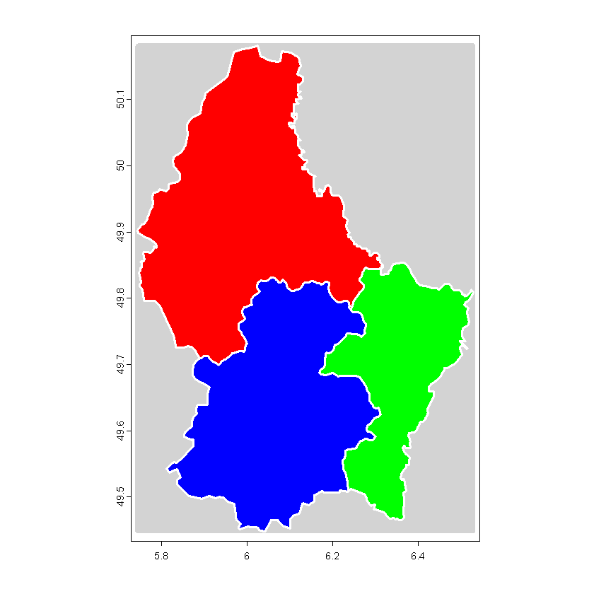

```r
plot(za, col='light gray', border='light gray', lwd=5)
plot(pa, add=TRUE, col=rainbow(3), lwd=3, border='white')
```

- 테두리를 분해하지 않고 다각형을 집계

1. 4

2. 1

1. 1

2. 0

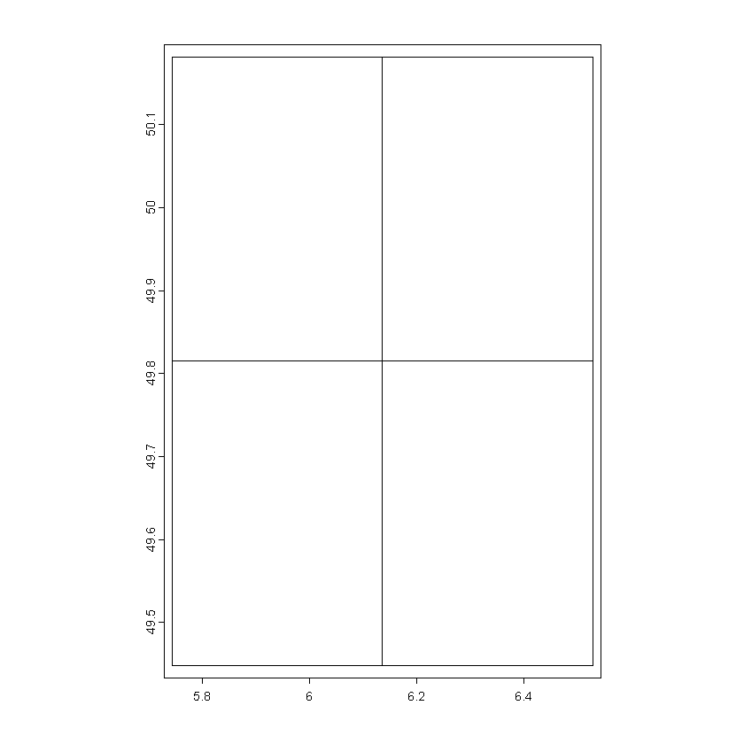

```r
zag = aggregate(z, dissolve = F)
dim(z); dim(zag)
plot(zag)
```

#### `disagg()` : 하나의 엔터티 (한 행)로 표현되는 여러 다각형 생성

1. 1

2. 0

1. 4

2. 0

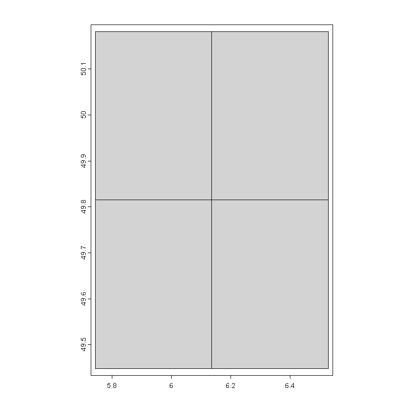

```r
zd <- disagg(zag)
dim(zag); dim(zd)

plot(zd, col = 'lightgray')
```

### 덮어 씌우기 (overlay)

#### 1. 제거법 (Erase)

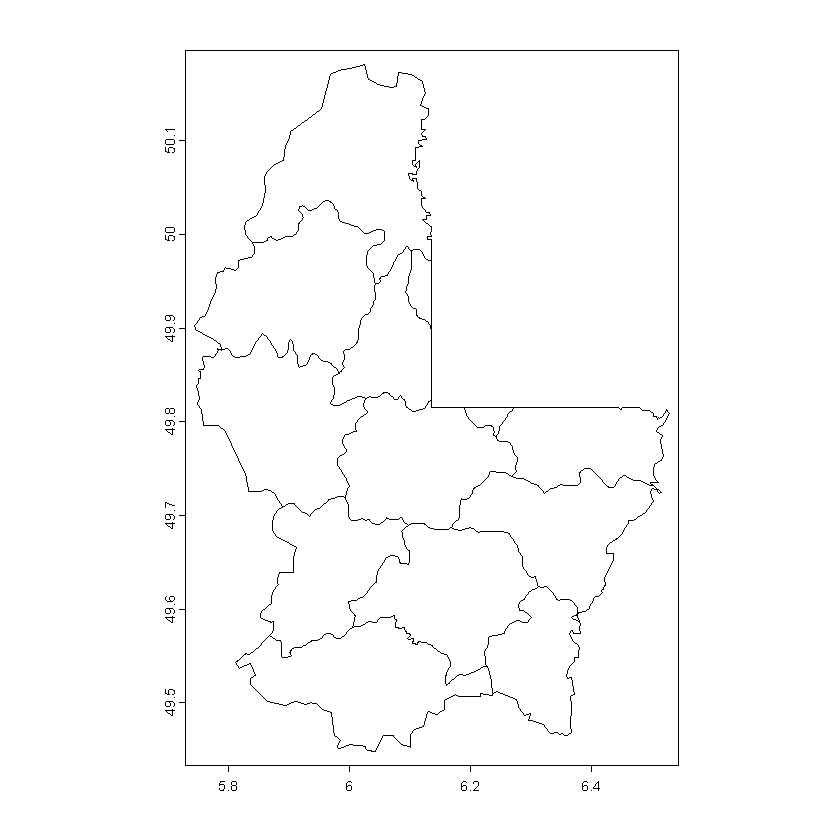

```r
e <- terra::erase(p, z2)
plot(e)
```

#### 2. 교차 (Intersect)

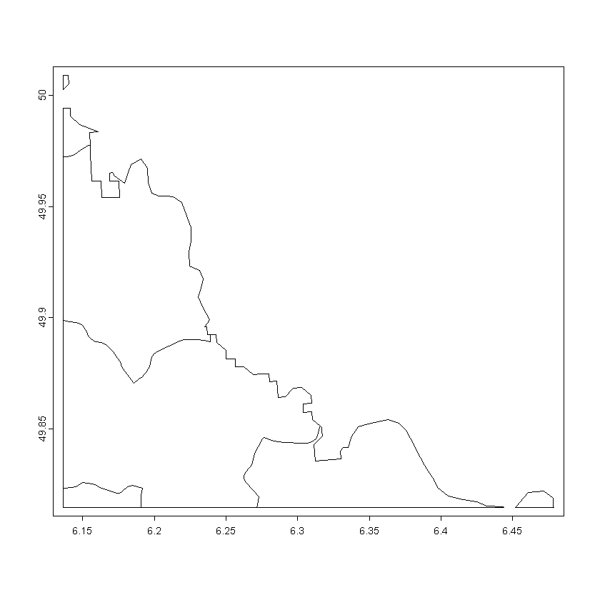

```r
i <- terra::intersect(p, z2)
plot(i)
```

#### 3. 잘라내기 (Crop)

```r
e <- ext(6, 6.4, 49.7, 50)
pe <- crop(p, e)
```

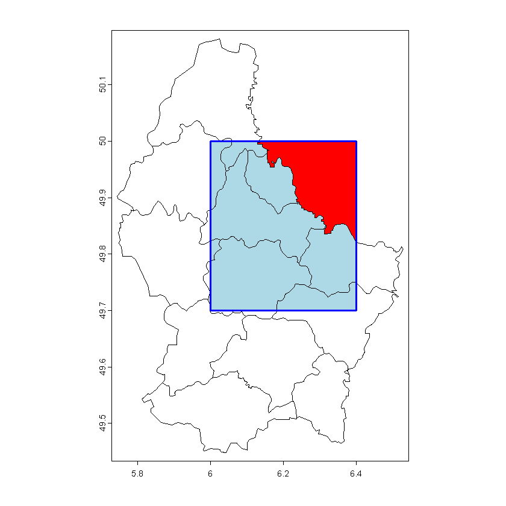

```r
plot(p)
plot(e, add=TRUE, lwd=3, col="red")
plot(pe, col='light blue', add=TRUE)
plot(e, add=TRUE, lwd=3, border="blue")
```

#### 4. 통합 (Union)

```r
u <- terra::union(p, z)
dim(p); dim(z); dim(u)
```

1. 12

2. 6

1. 4

2. 1

1. 28

2. 7

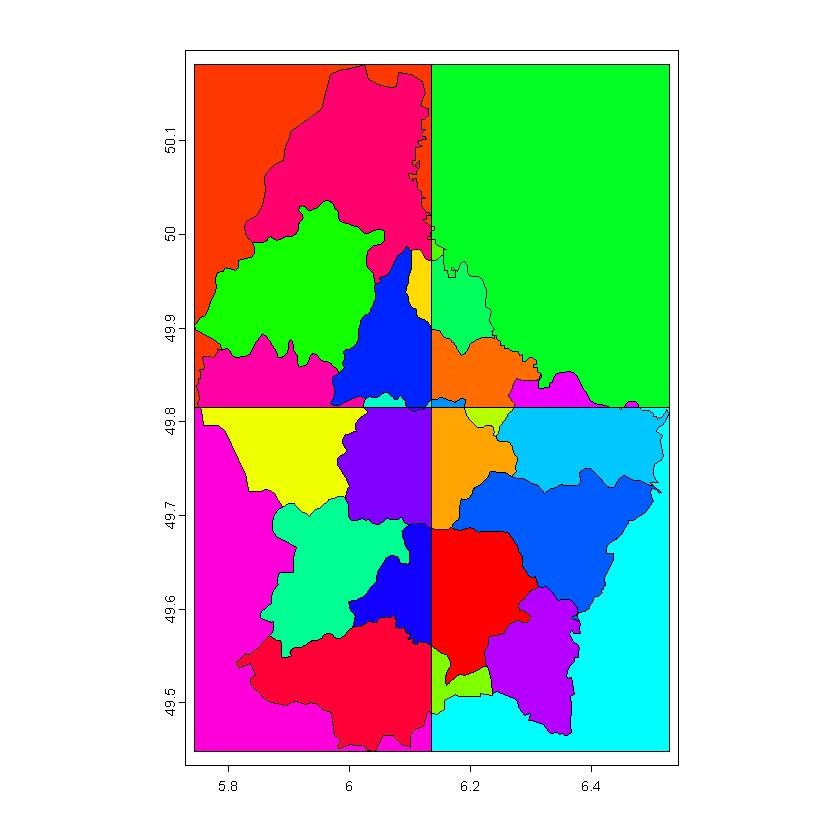

```r
set.seed(5)
plot(u, col=sample(rainbow(length(u))))
```

#### 5. 덮어 씌우기 (Cover)

```r
cov <- terra::cover(p, z[c(1,4),])
dim(p); dim(z[c(1, 4), ]); dim(cov)
```

1. 12

2. 6

1. 2

2. 1

1. 11

2. 7

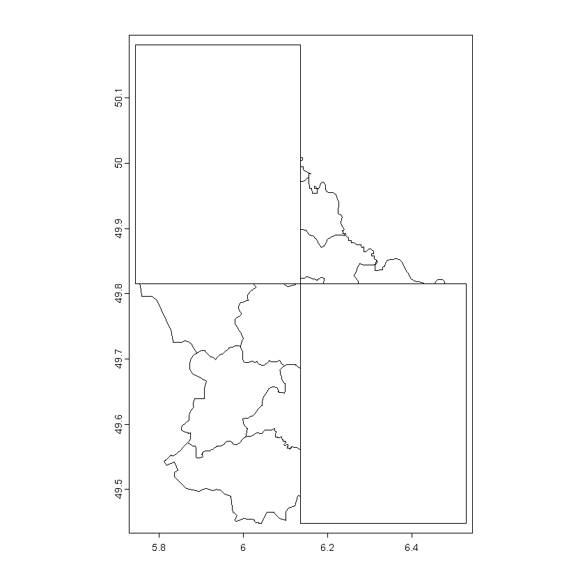

```r
plot(cov)
```

#### 6. 차이 계산 (difference, symdif)

```r
dif <- terra::symdif(z,p)
dim(z); dim(p); dim(dif)
```

1. 4

2. 1

1. 12

2. 6

1. 4

2. 1

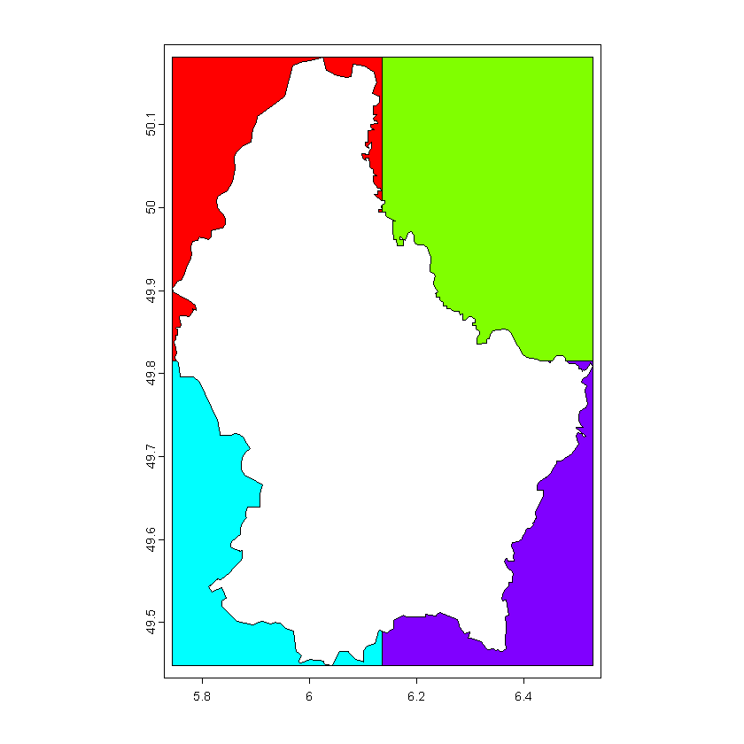

```r
plot(dif, col=rainbow(length(dif)))
```

### 공간 쿼리

- 점을 사용하여 다각형을 쿼리 (Polygon 내 점을 쿼리)

```r
pts <- matrix(c(6, 6.1, 5.9, 5.7, 6.4, 50, 49.9, 49.8, 49.7, 49.5), ncol=2)
spts <- vect(pts, crs=crs(p))
```

```r
spts
```

```
 class       : SpatVector
 geometry    : points
 dimensions  : 5, 0  (geometries, attributes)
 extent      : 5.7, 6.4, 49.5, 50  (xmin, xmax, ymin, ymax)
 coord. ref. : lon/lat WGS 84 (EPSG:4326)
```

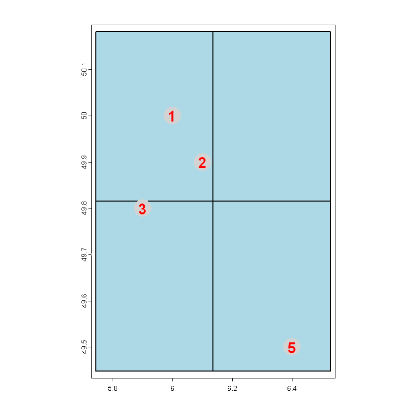

```r
plot(z, col='light blue', lwd=2)
points(spts, col='light gray', pch=20, cex=6)
text(spts, 1:nrow(pts), col='red', font=2, cex=1.5)
```

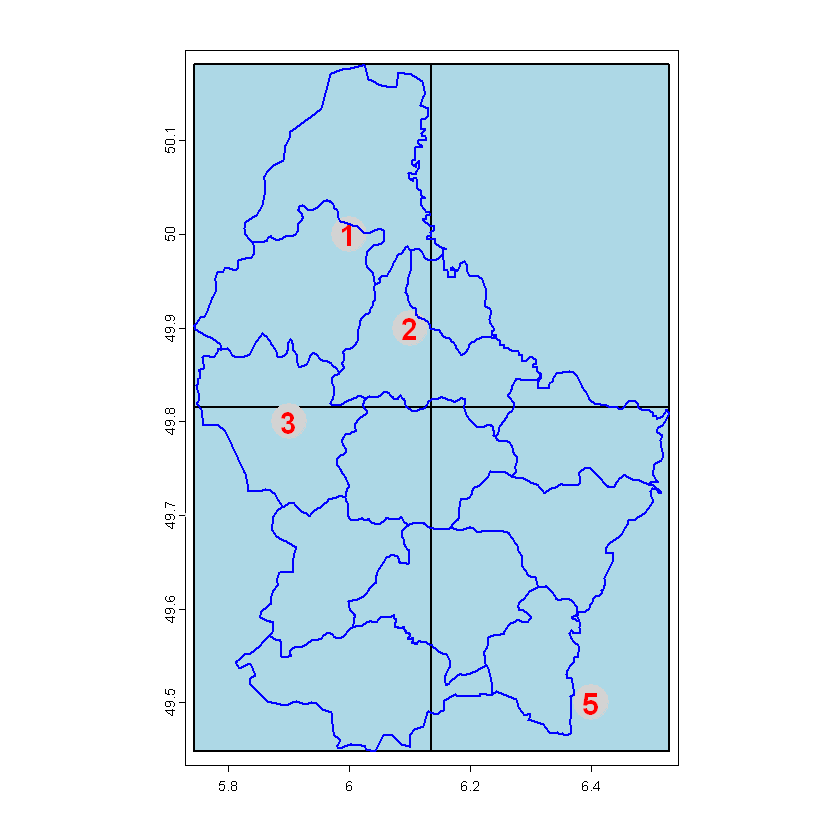

```r
plot(z, col='light blue', lwd=2)
points(spts, col='light gray', pch=20, cex=6)
text(spts, 1:nrow(pts), col='red', font=2, cex=1.5)
lines(p, col='blue', lwd=2)
```

#### `terra::extract()` : `SpatVector`, `SpatRaster`, `SpatVectors` 객체 간의 쿼리에도 적용 가능

```r
terra::extract(spts, p)
```

A matrix: 12 × 2 of type dbl

| id.y | id.x |
| --- | --- |
| 1 | NaN |
| 2 | NaN |
| 3 | NaN |
| 4 | NaN |
| 5 | NaN |
| 6 | NaN |
| 7 | NaN |
| 8 | NaN |
| 9 | NaN |
| 10 | NaN |
| 11 | NaN |
| 12 | NaN |

```r
(terra::extract(spts, z))
```

A matrix: 4 × 2 of type dbl

| id.y | id.x |
| --- | --- |
| 1 | NaN |
| 2 | NaN |
| 3 | NaN |
| 4 | NaN |

## 01.07. `Raster` 데이터 조작

### `SpatRaster` 객체 생성

#### `terra::rast()`

- 경도/위도 CRS와 1x1도 셀을 사용하여, `Raster` 구조 생성
  - `xmin`, `nrow`, `ncol`, `crs` 등의 파라미터로 설정 변경 가능
- 다른 조표계로 변환 (투영)하려면 `project` 기능 사용

#### `rast()`로 `Raster` 객체 생성

```r
library(terra)
```

```r
x <- rast(); x
```

```
class       : SpatRaster
dimensions  : 180, 360, 1  (nrow, ncol, nlyr)
resolution  : 1, 1  (x, y)
extent      : -180, 180, -90, 90  (xmin, xmax, ymin, ymax)
coord. ref. : lon/lat WGS 84 (CRS84) (OGC:CRS84)
```

```r
x <- rast(ncol=36, nrow=18, xmin=-1000, xmax=1000, ymin=-100, ymax=900); x
```

```
class       : SpatRaster
dimensions  : 18, 36, 1  (nrow, ncol, nlyr)
resolution  : 55.55556, 55.55556  (x, y)
extent      : -1000, 1000, -100, 900  (xmin, xmax, ymin, ymax)
coord. ref. :
```

#### `Raster` 객체의 매개변수 변경

- 해상도 변경

```r
res(x)
```

1. 55.5555555555556

2. 55.5555555555556

```r
res(x) <- 100
res(x)
```

1. 100

2. 100

- 차원 변경

```r
ncol(x)
ncol(x) <- 18

ncol(x); res(x)
```

20

18

1. 111.111111111111

2. 100

- 범위 변경

```r
ext(x) <- c(-180, 180, -90, 90)
ext(x)
```

```
SpatExtent : -180, 180, -90, 90 (xmin, xmax, ymin, ymax)
```

```r
ncol(x); res(x)
```

18

1. 20

2. 18

- `Raster`객체의 값 부여

```r
r <- rast(ncol=10, nrow=10)
ncell(r)
hasValues(x)
```

100

FALSE

```r
values(r) <- 1:ncell(r)
```

```r
set.seed(0)
values(r) <- runif(ncell(r))
hasValues(r)
```

TRUE

```r
sources(r)
```

''

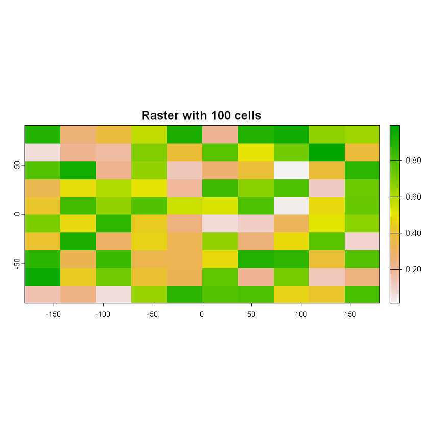

```r
plot(r, main='Raster with 100 cells')
```

- `Raster`객체의 열이나 행의 수를 변경할 때, `SpatRaster`과 값이 손실될 수 있으며, 해상도를 변경할 때도, 행 또는 열 수에 영향을 미칠 수 있음
- 범위를 변경하면 해상도가 조정되지만, 행이나 열 수는 변경되지 않으므로, 값이 손실되지 않음

```r
hasValues(r)
res(r); dim(r); ext(r)
```

TRUE

1. 36

2. 18

1. 10

2. 10

3. 1

```
SpatExtent : -180, 180, -90, 90 (xmin, xmax, ymin, ymax)
```

- `SpatRaster` 범위의 최대 x값 변경

```r
xmax(r)
xmax(r) <- 0
xmax(r)
```

180

0

```r
res(r); dim(r)
```

1. 18

2. 18

1. 10

2. 10

3. 1

- `Raster` 객체의 열 수 변경

```r
ncol(r)
ncol(r) <- 6
ncol(r)
```

10

6

```r
res(r); dim(r); xmax(r)
```

1. 30

2. 18

1. 10

2. 6

3. 1

0

#### 파일을 통한 `SpatRaster` 객체 생성

- `terra` 패키지는 `GeoTiff`, `ESRI`, `ENVI`, `ERDAS`를 포함한 여러 파일 사용 가능
  - 메모리(RAM)에 로드하기 너무 큰 `Raster` 데이터 세트와 함께 작동 가능

```r
library(tidyverse)
```

```r
r = rast('elev.tif')
```

```r
dim(r)
```

1. 90

2. 95

3. 1

```r
hasValues(r)
```

TRUE

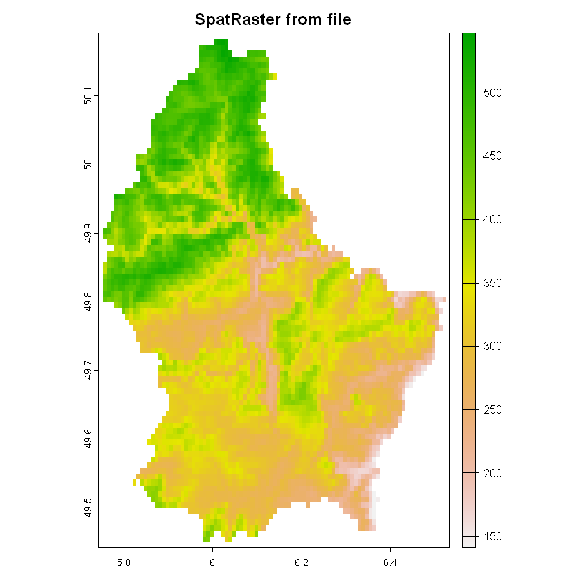

```r
plot(r, main = "SpatRaster from file")
```

#### 다중 레이어 객체 생성

```r
r1 <- r2 <- r3 <- rast(nrow = 10, ncol = 10)
```

```r
values(r1) <- runif(ncell(r1))
values(r2) <- runif(ncell(r2))
values(r3) <- runif(ncell(r3))
```

```r
s <- c(r1, r2, r3)
s
```

```
class       : SpatRaster
dimensions  : 10, 10, 3  (nrow, ncol, nlyr)
resolution  : 36, 18  (x, y)
extent      : -180, 180, -90, 90  (xmin, xmax, ymin, ymax)
coord. ref. : lon/lat WGS 84 (CRS84) (OGC:CRS84)
source(s)   : memory
names       :      lyr.1,      lyr.1,      lyr.1
min values  : 0.01307758, 0.02778712, 0.06380247
max values  : 0.99268406, 0.98156346, 0.99607737
```

```r
dim(s)
```

1. 10

2. 10

3. 3

#### 파일을 통한 다중 레이어 객체 생성

```r
b = rast('logo.tif')
b
nlyr(b)
```

```
class       : SpatRaster
dimensions  : 77, 101, 3  (nrow, ncol, nlyr)
resolution  : 1, 1  (x, y)
extent      : 0, 101, 0, 77  (xmin, xmax, ymin, ymax)
coord. ref. : Cartesian (Meter)
source      : logo.tif
colors RGB  : 1, 2, 3
names       : red, green, blue
min values  :   0,     0,    0
max values  : 255,   255,  255
```

3

- 레이어 추출

```r
r <- b[[2]]
```

### `Raster` 대수학

```r
r <- rast(ncol = 10, nrow = 10)
values(r) <- 1:ncell(r)
```

- `Raster`객체 값에 대한 연산

```r
s <- r + 10
s <- sqrt(s)
s <- s * r + 5
s
```

```
class       : SpatRaster
dimensions  : 10, 10, 1  (nrow, ncol, nlyr)
resolution  : 36, 18  (x, y)
extent      : -180, 180, -90, 90  (xmin, xmax, ymin, ymax)
coord. ref. : lon/lat WGS 84 (CRS84) (OGC:CRS84)
source(s)   : memory
name        :       lyr.1
min value   :    8.316625
max value   : 1053.808848
```

```r
values(r) <- runif(ncell(r))
r <- round(r)
r <- r == 1

r
```

```
class       : SpatRaster
dimensions  : 10, 10, 1  (nrow, ncol, nlyr)
resolution  : 36, 18  (x, y)
extent      : -180, 180, -90, 90  (xmin, xmax, ymin, ymax)
coord. ref. : lon/lat WGS 84 (CRS84) (OGC:CRS84)
source(s)   : memory
name        : lyr.1
min value   : FALSE
max value   :  TRUE
```

- 값 대체

```r
s[r] <- -0.5
s[!r] <- 5
s[s == 5] <- 15

s
```

```
class       : SpatRaster
dimensions  : 10, 10, 1  (nrow, ncol, nlyr)
resolution  : 36, 18  (x, y)
extent      : -180, 180, -90, 90  (xmin, xmax, ymin, ymax)
coord. ref. : lon/lat WGS 84 (CRS84) (OGC:CRS84)
source(s)   : memory
name        : lyr.1
min value   :  -0.5
max value   :  15.0
```

- 여러 `SpatRaster` 객체를 사용하는 경우, **동일한 해상도와 원점을 가져야 함**
- **`Raster` 객체의 원점은 `SpatRaster`의 모서리에서, 입력된 x 및 y 해상도 기준, 해당 지점을 향해 이동하면 얻을 수 있는 (0, 0)에 가장 가까운 지점**
- **동일한 범위를 갖지 않는 경우, 반환 값은 사용된 객체들의 공간 교차점을 포함하게 됨**

```r
r <- rast(ncol=5, nrow=5)
values(r) <- 1
r[[1]]
dim(r)
```

```
class       : SpatRaster
dimensions  : 5, 5, 1  (nrow, ncol, nlyr)
resolution  : 72, 36  (x, y)
extent      : -180, 180, -90, 90  (xmin, xmax, ymin, ymax)
coord. ref. : lon/lat WGS 84 (CRS84) (OGC:CRS84)
source(s)   : memory
name        : lyr.1
min value   :     1
max value   :     1
```

1. 5

2. 5

3. 1

```r
s <- c(r, r+1)
s
dim(s)
```

```
class       : SpatRaster
dimensions  : 5, 5, 2  (nrow, ncol, nlyr)
resolution  : 72, 36  (x, y)
extent      : -180, 180, -90, 90  (xmin, xmax, ymin, ymax)
coord. ref. : lon/lat WGS 84 (CRS84) (OGC:CRS84)
source(s)   : memory
names       : lyr.1, lyr.1
min values  :     1,     2
max values  :     1,     2
```

1. 5

2. 5

3. 2

```r
q <- c(r, r+2, r+4, r+6)
dim(q)
```

1. 5

2. 5

3. 4

```r
x <- r + s + q
dim(x)
```

1. 5

2. 5

3. 4

- 요약함수 (`min`, `max`, `mean`, `prod`, `sum`, `median`, `cv`, `range`, `any`, `all`)는 항상 `SpatRaster` 객체를 반환

```r
a <- mean(r, s)
dim(a)
a
```

1. 5

2. 5

3. 2

```
class       : SpatRaster
dimensions  : 5, 5, 2  (nrow, ncol, nlyr)
resolution  : 72, 36  (x, y)
extent      : -180, 180, -90, 90  (xmin, xmax, ymin, ymax)
coord. ref. : lon/lat WGS 84 (CRS84) (OGC:CRS84)
source(s)   : memory
names       : lyr1, lyr2
min values  :    1,  1.5
max values  :    1,  1.5
```

- **서로 다른 레이어를 가진 다중 레이어 객체들을 사용하면, 가장 차원 값을 가진 객체가 기준이 됨**

```r
st <- c(r, s, a)
sst <- sum(st)
sst; dim(sst)
```

```
class       : SpatRaster
dimensions  : 5, 5, 1  (nrow, ncol, nlyr)
resolution  : 72, 36  (x, y)
extent      : -180, 180, -90, 90  (xmin, xmax, ymin, ymax)
coord. ref. : lon/lat WGS 84 (CRS84) (OGC:CRS84)
source(s)   : memory
name        : sum
min value   : 6.5
max value   : 6.5
```

1. 5

2. 5

3. 1

#### `global()` : 각 레이어의 셀 값을 요약

```r
global(st, 'sum')
```

A data.frame: 5 × 1

|  | sum <dbl> |
| --- | --- |
| lyr.1 | 25.0 |
| lyr.1.1 | 25.0 |
| lyr.1.2 | 50.0 |
| lyr1 | 25.0 |
| lyr2 | 37.5 |

```r
r <- rast(ncol=36, nrow=18)
values(r) <- runif(ncell(r))
global(r, mean)
```

A data.frame: 1 × 1

|  | mean <dbl> |
| --- | --- |
| lyr.1 | 0.4999551 |

#### `zonal()` : 셀별 요약

```r
s <- r
values(s) <- round(runif(ncell(r)) * 5)
s
```

```
class       : SpatRaster
dimensions  : 18, 36, 1  (nrow, ncol, nlyr)
resolution  : 10, 10  (x, y)
extent      : -180, 180, -90, 90  (xmin, xmax, ymin, ymax)
coord. ref. : lon/lat WGS 84 (CRS84) (OGC:CRS84)
source(s)   : memory
name        : lyr.1
min value   :     0
max value   :     5
```

```r
zonal(r, s, 'mean')
```

A data.frame: 6 × 2

| lyr.1 <dbl> | lyr.1.1 <dbl> |
| --- | --- |
| 0 | 0.5324867 |
| 1 | 0.4841959 |
| 2 | 0.5133921 |
| 3 | 0.5084239 |
| 4 | 0.5128121 |
| 5 | 0.4241003 |

#### `freq()` : 레이어별 값 빈도

```r
freq(s)
```

A data.frame: 6 × 3

| layer <dbl> | value <dbl> | count <dbl> |
| --- | --- | --- |
| 1 | 0 | 80 |
| 1 | 1 | 127 |
| 1 | 2 | 130 |
| 1 | 3 | 112 |
| 1 | 4 | 133 |
| 1 | 5 | 66 |

#### `crosstab()` : 교차표 생성

```r
ctb <- crosstab(c(r*3, s))
head(ctb)
```

```
     lyr.1.1
lyr.1  0  1  2  3  4  5
    0 12 22 21 23 22 13
    1 25 42 43 30 43 32
    2 25 49 45 39 42 14
    3 18 14 21 20 26  7
```

#### 도움 함수

- `Raster`데이터는 행렬로 간주되지만, `SpatRaster` 벡터로 간주
- 셀 번호는 왼쪽 상단 부터 오른쪽 상단까지 매겨지며, 다음 행의 왼쪽에서 동일 방식이 적용

#### `rowFremCell()` / `colFromCell()` / `cellFromRowCol()` / `xyFromCell()` / `cellFromXY` / `cellFromX` / `cellFromY`: 셀의 열 또는 행 번호를 확인하는 도움 함수

```r
r <- rast(ncol = 36, nrow = 18)
ncol(r); nrow(r); ncell(r)
```

36

18

648

```r
r
```

```
class       : SpatRaster
dimensions  : 18, 36, 1  (nrow, ncol, nlyr)
resolution  : 10, 10  (x, y)
extent      : -180, 180, -90, 90  (xmin, xmax, ymin, ymax)
coord. ref. : lon/lat WGS 84 (CRS84) (OGC:CRS84)
```

- 100번 째 값의 행 / 열

```r
rowFromCell(r, 100); colFromCell(r, 100)
```

3

28

- 5행, 5열의 값

```r
cellFromRowCol(r,5,5)
```

149

- 100번째 셀에 대한 좌표

```r
xyFromCell(r, 100)
```

A matrix: 1 × 2 of type dbl

| x | y |
| --- | --- |
| 95 | 65 |

- (0, 0) 좌표에 대한 셀 번호

```r
cellFromXY(r, cbind(0,0))
```

343

```r
colFromX(r, 0); rowFromY(r, 0)
```

19

10

### 셀 값 추출

```r
r <- rast("elev.tif")
v <- values(r)
```

```r
sources(r)
```

'C:/Users/user/Documents/Spatial Data Science with R/elev.tif'

```r
v[3075:3080, ]
```

1. 324

2. 288

3. 342

4. 313

5. 311

6. 291

```r
values(r, row=33, nrow=1, col=35, ncol=6)
```

A matrix: 6 × 1 of type int

| elevation |
| --- |
| 324 |
| 288 |
| 342 |
| 313 |
| 311 |
| 291 |

```r
cells <- cellFromRowCol(r, 33, 35:44)
cells
```

1. 3075

2. 3076

3. 3077

4. 3078

5. 3079

6. 3080

7. 3081

8. 3082

9. 3083

10. 3084

```r
r[cells]
```

A data.frame: 10 × 1

| elevation <int> |
| --- |
| 324 |
| 288 |
| 342 |
| 313 |
| 311 |
| 291 |
| 365 |
| 395 |
| 430 |
| 407 |

```r
xy <- xyFromCell(r, cells)
xy
```

A matrix: 10 × 2 of type dbl

| x | y |
| --- | --- |
| 6.029167 | 49.92083 |
| 6.037500 | 49.92083 |
| 6.045833 | 49.92083 |
| 6.054167 | 49.92083 |
| 6.062500 | 49.92083 |
| 6.070833 | 49.92083 |
| 6.079167 | 49.92083 |
| 6.087500 | 49.92083 |
| 6.095833 | 49.92083 |
| 6.104167 | 49.92083 |

```r
terra::extract(r, xy)
```

A data.frame: 10 × 1

| elevation <int> |
| --- |
| 324 |
| 288 |
| 342 |
| 313 |
| 311 |
| 291 |
| 365 |
| 395 |
| 430 |
| 407 |

### 다른 객체로 변환

```r
r <- rast(ncol = 36, nrow = 18)
values(r) <- runif(ncell(r))
class(r)
```

'SpatRaster'

```r
library(raster)
```

```r
x <- raster(r)
class(x)
```

'RasterLayer'

## 01.08. 시각화

### `SpatVector`

```r
p <- vect('./ex/lux.shp')
p
```

```
 class       : SpatVector
 geometry    : polygons
 dimensions  : 12, 6  (geometries, attributes)
 extent      : 5.74414, 6.528252, 49.44781, 50.18162  (xmin, xmax, ymin, ymax)
 source      : lux.shp
 coord. ref. : lon/lat WGS 84 (EPSG:4326)
 names       :  ID_1   NAME_1  ID_2   NAME_2  AREA   POP
 type        : <num>    <chr> <num>    <chr> <num> <int>
 values      :     1 Diekirch     1 Clervaux   312 18081
                   1 Diekirch     2 Diekirch   218 32543
                   1 Diekirch     3  Redange   259 18664
```

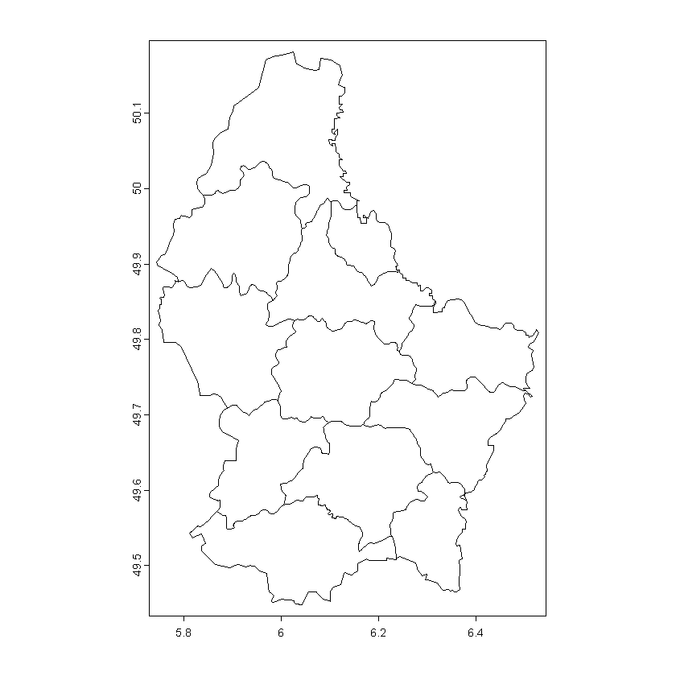

```r
plot(p)
```

- 색 추가

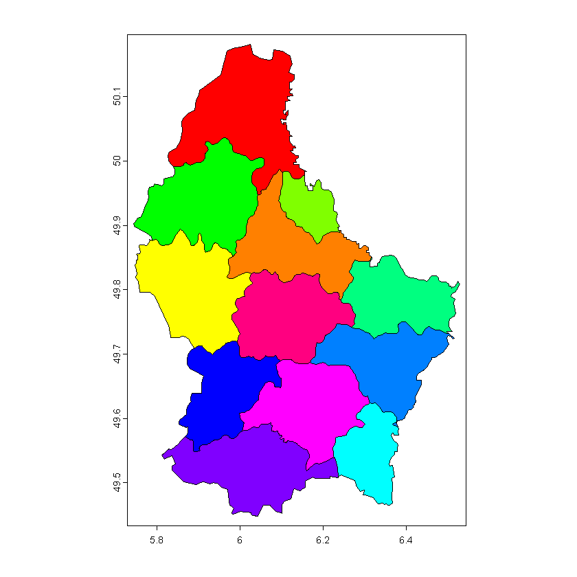

```r
n <- nrow(p)
plot(p, col = rainbow(n))
```

- 범례 추가

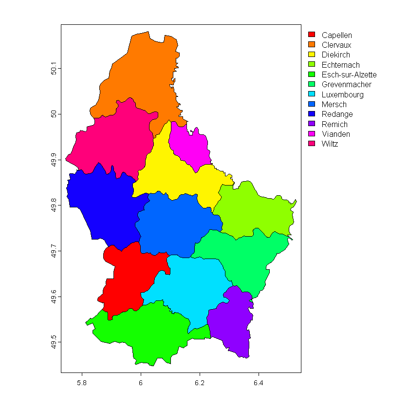

```r
plot(p, "NAME_2", col = rainbow(25))
```

- 레이어 별 시각화

```r
names(p)
```

1. 'ID_1'

2. 'NAME_1'

3. 'ID_2'

4. 'NAME_2'

5. 'AREA'

6. 'POP'

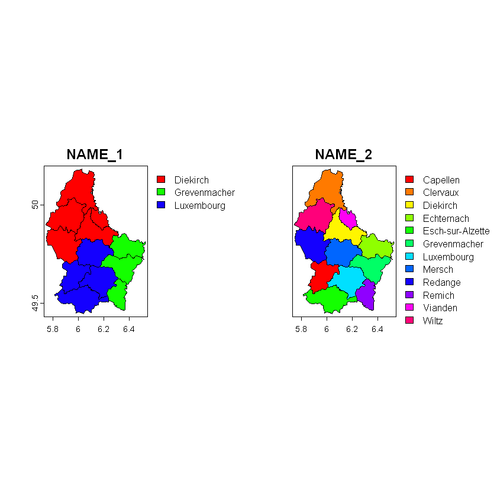

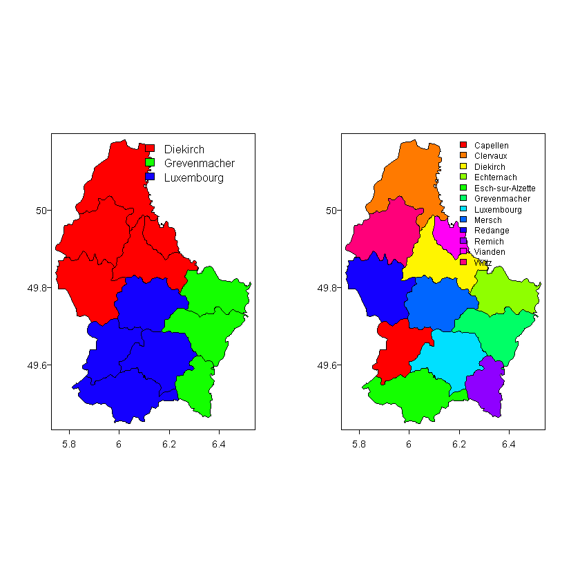

```r
plot(p, c("NAME_1", "NAME_2"), col = rainbow(25))

par(mfrow=c(1,2))
m <- c(3.1, 3.1, 2.1, 2.1)
plot(p, "NAME_1", col=rainbow(25), mar=m, plg=list(x="topright"), pax=list(las=1))
plot(p, "NAME_2", col=rainbow(25), mar=m, plg=list(x="topright", cex=.75), pax=list(las=1))
```

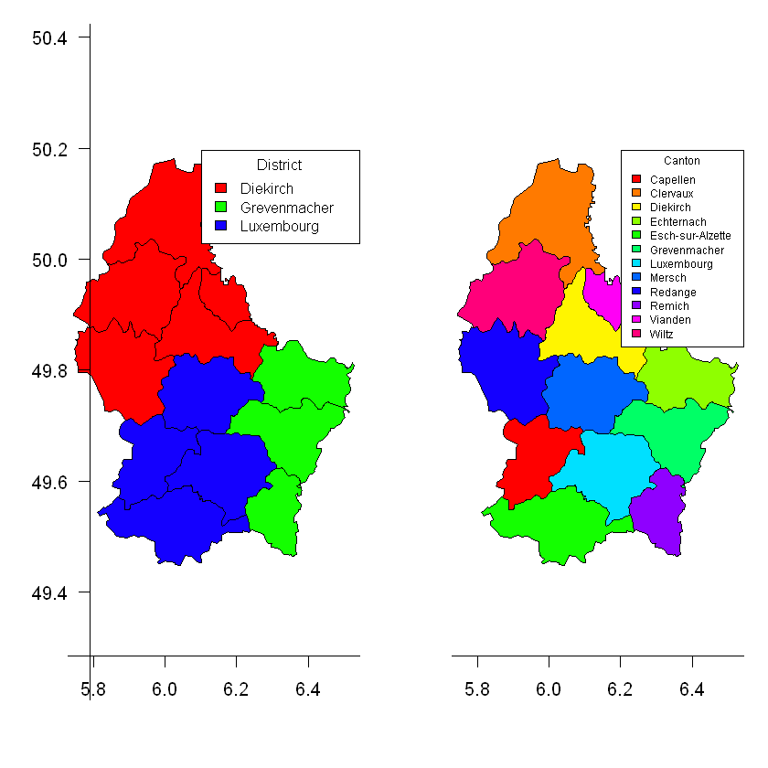

```r
par(mfrow=c(1,2))
m <- c(3.1, 3.1, 1.1, 1.1)
plot(p, "NAME_1", col=rainbow(25), mar=m, plg=list(x="topright", title="District", bty = "o"), main="", axes=FALSE)
axis(1, at=c(5,7)); axis(1)
axis(2, at=c(49,51)); axis(2, las=1)
plot(p, "NAME_2", col=rainbow(25), mar=m, plg=list(x="topright", cex=.75, title="Canton", bty = "o"), main="", axes=FALSE)
axis(1, at=c(5, 7)); axis(1)
```

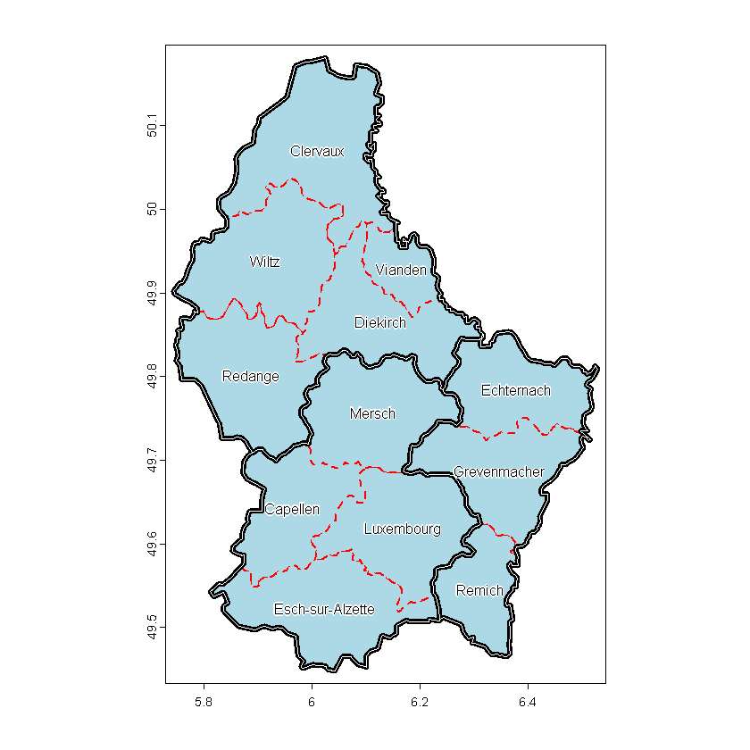

```r
d <- aggregate(p, "NAME_1")
plot(p, col="light blue", lty=2, border="red", lwd=2)
lines(d, lwd=5)
lines(d, col="white", lwd=1)
text(p, "NAME_2", cex=.8, halo=TRUE)
```

### `SpatRaster`

```r
r <- rast('./ex/elev.tif')
r
```

```
class       : SpatRaster
dimensions  : 90, 95, 1  (nrow, ncol, nlyr)
resolution  : 0.008333333, 0.008333333  (x, y)
extent      : 5.741667, 6.533333, 49.44167, 50.19167  (xmin, xmax, ymin, ymax)
coord. ref. : lon/lat WGS 84 (EPSG:4326)
source      : elev.tif
name        : elevation
min value   :       141
max value   :       547
```

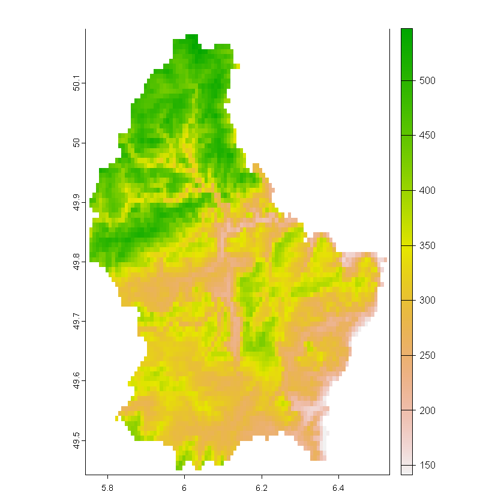

```r
plot(r)
```

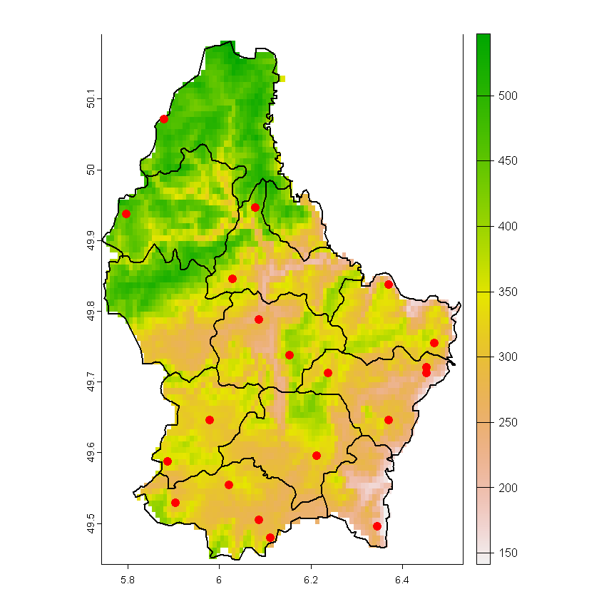

```r
plot(r)
lines(p, lwd=2)
set.seed(12)
xy <- spatSample(r, 20, "random", na.rm=TRUE, xy=TRUE)
points(xy, pch=20, col="red", cex=2)
```

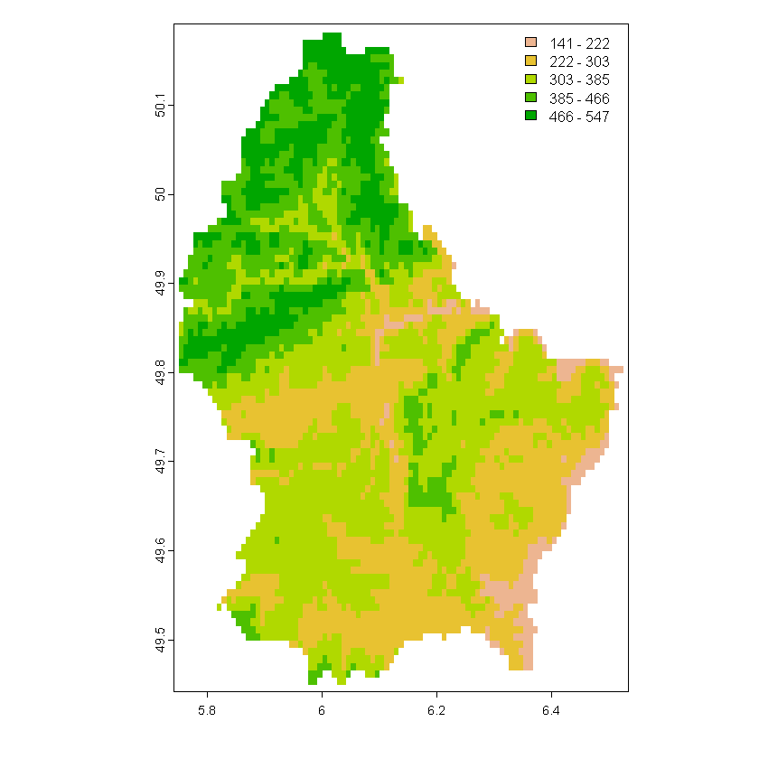

```r
m <- c(3.1, 3.1, 1.1, 1.1)
plot(r, type="interval", plg=list(x="topright"), mar=m)
```

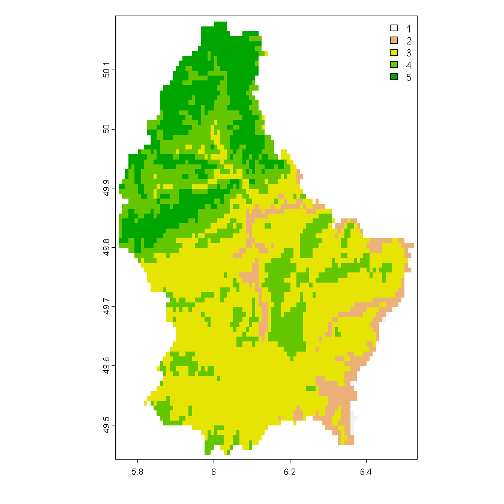

```r
rr <- round(r/100)
plot(rr, plg=list(x="topright"), mar=m)
```

#### 범주형 `SpatRaster`

```r
x <- classify(r, c(140, 300, 400, 550))
```

```r
x
```

```
class       : SpatRaster
dimensions  : 90, 95, 1  (nrow, ncol, nlyr)
resolution  : 0.008333333, 0.008333333  (x, y)
extent      : 5.741667, 6.533333, 49.44167, 50.19167  (xmin, xmax, ymin, ymax)
coord. ref. : lon/lat WGS 84 (EPSG:4326)
source(s)   : memory
varname     : elev
categories  : elevation
name        : elevation
min value   : (140–300]
max value   : (400–550]
```

```r
levels(x) <- data.frame(id=0:2, elevation=c("low", "intermediate", "high"))
is.factor(x)
```

TRUE

```r
x
```

```
class       : SpatRaster
dimensions  : 90, 95, 1  (nrow, ncol, nlyr)
resolution  : 0.008333333, 0.008333333  (x, y)
extent      : 5.741667, 6.533333, 49.44167, 50.19167  (xmin, xmax, ymin, ymax)
coord. ref. : lon/lat WGS 84 (EPSG:4326)
source(s)   : memory
varname     : elev
categories  : elevation
name        : elevation
min value   :       low
max value   :      high
```

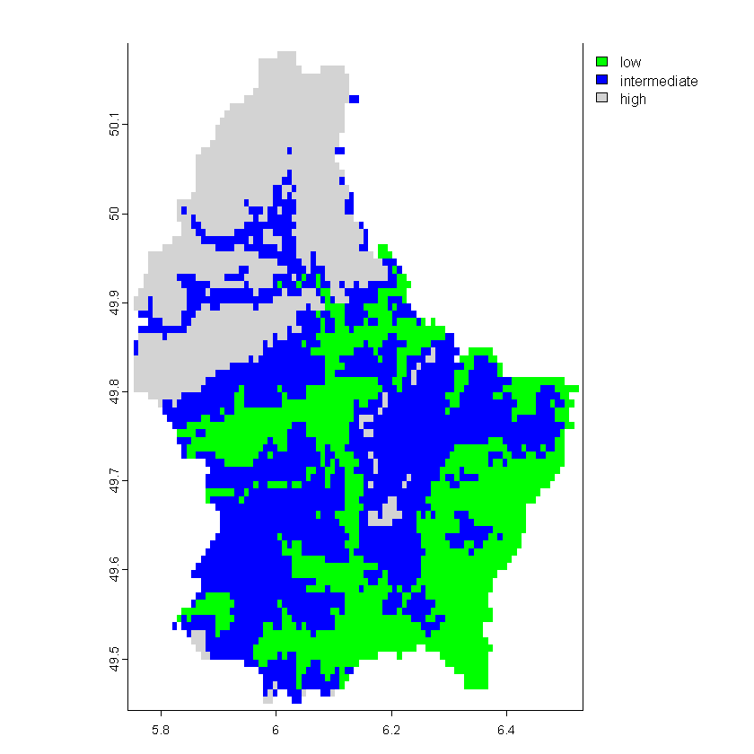

```r
plot(x, col=c("green", "blue", "light gray"))
```

#### 다중 레이어 객체

```r
b <- rast("ex/logo.tif")
```

[figure not shown]

```r
plot(b)
```

```r
r <- rast(p, res=0.01 )
values(r) <- 1:ncell(r)
r <- mask(r, p)
```

```r
r
```

```
class       : SpatRaster
dimensions  : 73, 78, 1  (nrow, ncol, nlyr)
resolution  : 0.01, 0.01  (x, y)
extent      : 5.74414, 6.52414, 49.44781, 50.17781  (xmin, xmax, ymin, ymax)
coord. ref. : lon/lat WGS 84 (EPSG:4326)
source(s)   : memory
name        : lyr.1
min value   :    23
max value   :  5652
```

[figure not shown]

```r
plotRGB(b, r=1, g=2, b=3)
```

### 지도 시각화

```r
p <- vect('./ex/lux.shp')
```

```r
library(maptiles)
```

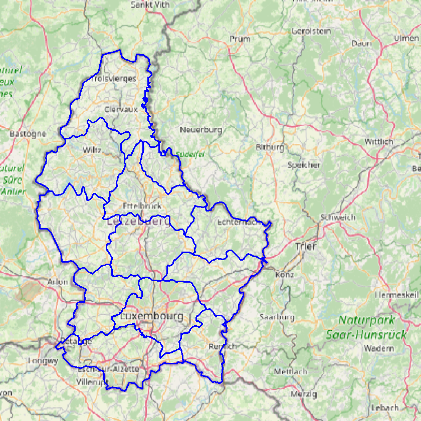

```r
bg <- get_tiles(ext(p))
plotRGB(bg)
lines(p, col="blue", lwd=3)
```

#### `leaflet`

```r
library(leaflet)
m <- plet(p)
m
```

[interactive chart not shown]